# hw2

Pablo,Román,Sofía

12/2/2020

##Ejercicio 1

Un outlier se define como una observación que cae más allá de las barras del boxplot, las barras o whiskers se definen como: $F_U + 1.5dF$ y $F_L −1.5dF$ , donde $F_L$ y $F_U$ los quartiles 1 y 3 respectivamente y dF es el rango intercuartil. El extremo suerior es el máximo del conjunto de datos. Responder las siguientes preguntas:

Recordemos que un valor que caiga 1.5 rangos intercuantiles abajo o arriba del quantil superior/inferior es un outlier.

a)¿Es el extremo superior siempre un outlier?

Por definición, el extemo superior es el dato mayor exluyendo a los outliers, es decir, no puede ser uno de ellos.

2. ¿Es posible para la media o la mediana quedar afuera de los cuartiles o incluso afuera de los whiskers?

Le mediana es la linea que divide la caja a la mitad, por lo que, nunca quedará afuera de los cuantiles, es uno como tal y menos podr??a estar fuera de los whiskers.Además, los whiskers representan una desviación estándar arriba y abajo de la media, entonces, tampoco puede estar fuera la media.

3. Supongan que los datos se distribuyen $N(0, 1)$. ¿Qué porcentaje de los datos esperan que caigan afuera de los whiskers?

Al observar la tabla z, podemos buscar el percentil 25 y el percentil 75, que son aproximadamente -0.675 y 0.675. Entonces, podemos obtener el l??mite inferior y el l??mite superior para el rango intercuantil $25 - 1.5 * (75 - 25)$ y $75 + 1.5 * (75 - 25)$, que es (-2.7,2.7).Entonces, tenemos 0.0035 de probabilidad a la izquierda (<-2.7) y 0.0035 de probabilidad a la derecha (> -2.7), entonces un total de 0.007 (0.7%) de probabilidad de estar fuera de os whiskers y ser outlier por lo tanto.

4. ¿Qué porcentaje de los datos se espera que caigan fuera de los whiskers si suponemos que los datos son normales con media 0 y varianza $\sigma^2$ desconocida?

##Ejercicio 2 2. Supongamos que tenemos 50 observaciones de una N (0,1) y otras 50 observaciones de una N (2, 1). ¿Cómo se verán las 100 caras de Chernoff si X y Y definen la línea de la cara y la oscuridad del cabello? ¿Esperan caras similares? ¿Cuántas caras lucen como observaciones de Y aún cuando son observaciones de X?

Como no encontramos los atributos de lina de la cara y oscuridad de cabello, usaremos lo mas proximo que encontramos que fue la estructura de la cara y el estilo de cabello. Esperamos que las caras no difieran tanto en cuanto a su estructura facial y con respecto a su estilo de cabello. Dado que lo unico que cambia es su media.

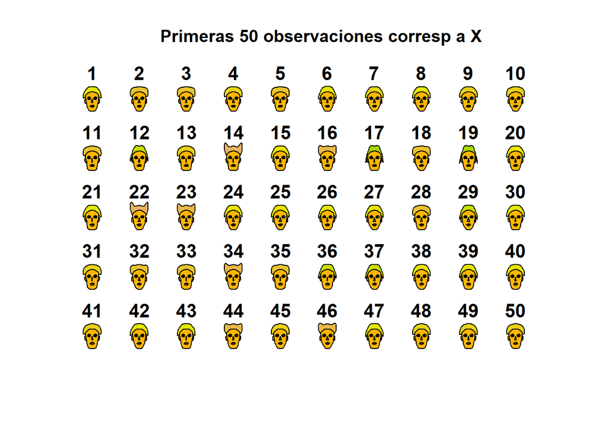

```
## effect of variables:
##  modified item       Var
##  "height of face   " "Var1"
##  "width of face    " "Var2"
##  "structure of face" "Var3"
##  "height of mouth  " "Var4"
##  "width of mouth   " "Var5"
##  "smiling          " "Var6"
##  "height of eyes   " "Var7"
##  "width of eyes    " "Var8"
##  "height of hair   " "Var9"
##  "width of hair   "  "Var10"
##  "style of hair   "  "Var11"
##  "height of nose  "  "Var12"
##  "width of nose   "  "Var13"
##  "width of ear    "  "Var14"
##  "height of ear   "  "Var15"
```

```r
library(aplpack)
# Primero creamos la matriz de estructura para las 100 caras de chernoff, con 15 entradas para sus atributos
CH <- matrix (rep(1,1500),ncol = 15)
X.2 <- rnorm(50)
Y.2 <- rnorm(50,2,1)

#x1.2 <- sample(c(X.2,Y.2))
#y1.2 <- sample(c(X.2,Y.2))

#La estructura de la cara, corresponde a la entrada 3, mientras que el estilo del cabello a la 11, es por eso que sustituimos aqui 50 observaciones de X y 50 de
CH[1:50,3] <- X.2
CH[1:50,11] <- Y.2
CH[1:50,3] <- sample(X.2)
CH[1:50,11] <- sample(Y.2)


faces(CH[1:50,],ncol.plot = 10, nrow.plot = 5, main= "Primeras 50 observaciones corresp a X")
```

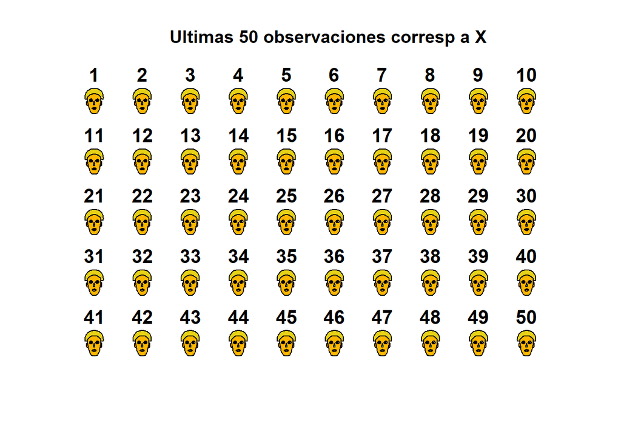

```
## effect of variables:
##  modified item       Var
##  "height of face   " "Var1"
##  "width of face    " "Var2"
##  "structure of face" "Var3"
##  "height of mouth  " "Var4"
##  "width of mouth   " "Var5"
##  "smiling          " "Var6"
##  "height of eyes   " "Var7"
##  "width of eyes    " "Var8"
##  "height of hair   " "Var9"
##  "width of hair   "  "Var10"
##  "style of hair   "  "Var11"
##  "height of nose  "  "Var12"
##  "width of nose   "  "Var13"
##  "width of ear    "  "Var14"
##  "height of ear   "  "Var15"
```

```r
faces(CH[51:100,],ncol.plot = 10, nrow.plot = 5, main = "Ultimas 50 observaciones corresp a X")
```

##Ejercicio 3 3 Usando las seis observaciones de la variable X1 en millones de dólares: a. Encuentra la proyección sobre $1'= (1, 1, 1, 1, 1, 1)$ b. Calcula el vector desviación $y_1 − \bar{x}_1$. Relaciona su longitud a la desviación estándar. c. Grafica (a escala) el triángulo formado por $y_1$,$\bar{x}_1$ y $y_1 − \bar{x}_1$. Identifica la longitud de cada vector en tu gráfica. d. Repetir los incisos (a) a (c) para X2 e. Grafica (a escala) los dos vectores desviación $y_1 − $ y $y_2 − \bar{x}_21$. Calcula el valor del ángulo entre ellos. f. Calcula la varianza muestral generalizada det(S) para estos datos e interpreta. g. Calcula la varianza muestral total tr(S) para estos datos e interpreta.

Para resolver el inciso a), utilizaremos la siguiente formula para obtener la proyección del vector $x$ sobre $y$.
$$proy(x,y)= \frac{x'y}{y'y}y$$
.

```r
# a)
proy <-function(x,y)
{
  (t(x)%*%y)[1]/(t(y)%*%y)[1]*y
}
unos <- rep(1,6)
(proy1 <- proy(X1.3,unos))
```

```
## [1] 2101179 2101179 2101179 2101179 2101179 2101179
```

Podemos observar que si dividimos la proyección obtenida es el vector $\bar{x}_11$.

```r
X1.3.mean <- mean(data3$x1)
X1.3.mean
```

```
## [1] 2101179
```

```r
proy1
```

```
## [1] 2101179 2101179 2101179 2101179 2101179 2101179
```

Para el inciso b) consideraremos que $y1$ es la primer columna de nuestros datos. Por lo cual procedmos de la siguiente manera para calcular el vector desviación.

```r
y1.3 <- as.array(data3$x1)
(d1.3 <- y1.3 - X1.3.mean)
```

```
## [1] 1396720.8  384295.8 -318304.2 -375729.2 -455604.2 -631379.2
```

Ahora para ilustrar la relacion entre su longitud y la desviacion estandar hacemos lo siguiente

```r
norm_vec <- function(x)
{
  sqrt(sum(x^2))
}
norm_vec(d1.3)
```

```
## [1] 1716746
```

```r
sd(X1.3)
```

```
## [1] 767752.2
```

```r
norm_vec(d1.3)/sqrt(5)
```

```
## [1] 767752.2
```

```r
sd(X1.3)
```

```
## [1] 767752.2
```

Para hacer el inciso c) reduciremos la complejidad del problema y nos limitaremos a solo usar las primeras dos entradas del vector $X_1$.

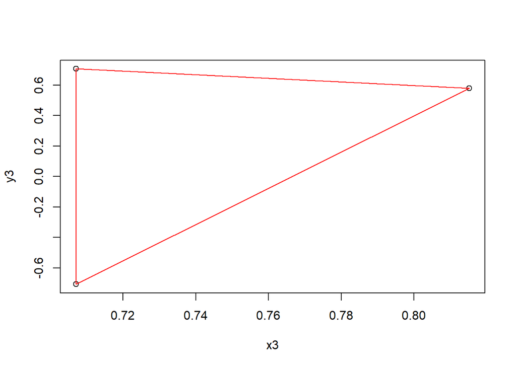

```r
x1.3 <- X1.3[c(1,2)]
x1.3.mean <- proy(x1.3,c(1,1))
d1 <- x1.3 - x1.3.mean

#normalizamos
x1.3 <- x1.3/norm_vec(x1.3)
x1.3.mean <- x1.3.mean/norm_vec(x1.3.mean)
d1 <- d1/norm_vec(d1)
data.3c <-rbind(x1.3,x1.3.mean,d1)
x3 <- as.array(data.3c[,1])
y3 <- as.array(data.3c[,2])
plot(x3,y3)
polygon(x3,y3, border = 'red')
```

Repetimos lo mismo para la segunda columna de nuestro data frame para realizar el incizo d).

Proyección sobre $1' = (1,1,1,1,1,1)$

```r
X2.3
```

```
## [1] 0.623 0.593 0.512 0.500 0.463 0.395
```

```r
(proy2 <- proy(X2.3,unos))
```

```
## [1] 0.5143333 0.5143333 0.5143333 0.5143333 0.5143333 0.5143333
```

Ahora calculamos el vector de desviacion. $y_2 - \bar{x}_2$ y verificamos su relacion con la desviacion estandar.

```r
(d2.3 <- X2.3 - proy2)
```

```
## [1]  0.108666667  0.078666667 -0.002333333 -0.014333333 -0.051333333
## [6] -0.119333333
```

```r
norm_vec(d2.3)/sqrt(5)
```

```
## [1] 0.08376555
```

```r
sd(X2.3)
```

```
## [1] 0.08376555
```

Por ultimo, realizamos la grafica del triangulo formado por $y_2$ $\bar{x}_2$ y $y_2 - \bar{x}_2$.

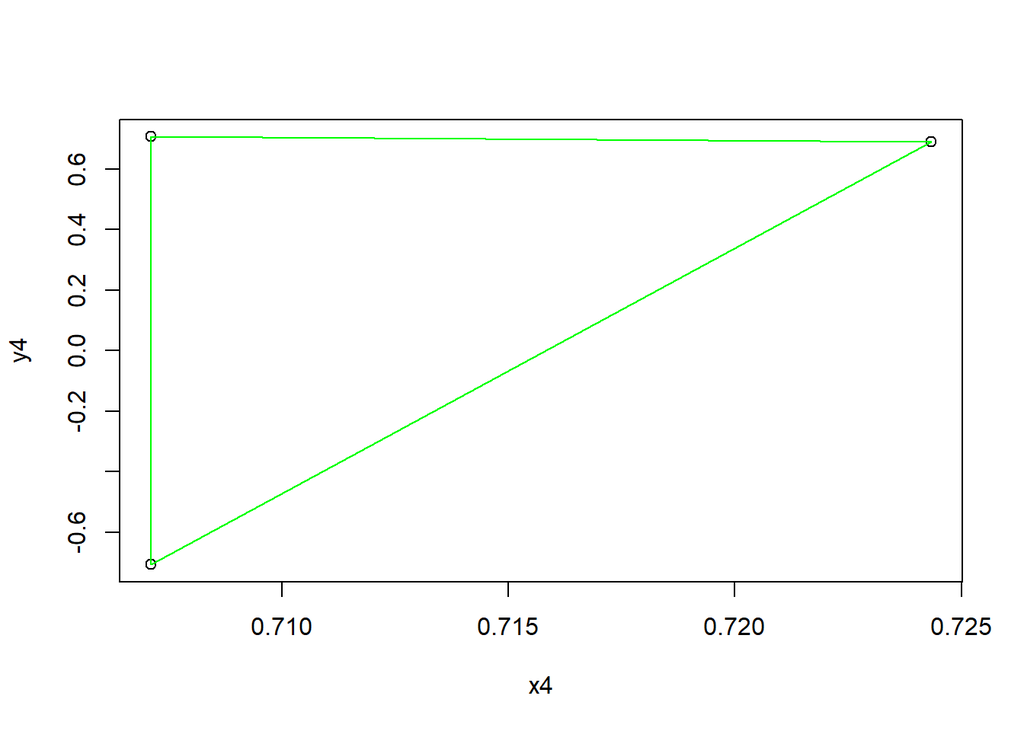

```r
x2.3 <- X2.3[c(1,2)]
x2.3.mean <- proy(x2.3,c(1,1))
d2 <- x2.3 - x2.3.mean

#normalizamos
x2.3 <- x2.3/norm_vec(x2.3)
x2.3.mean <- x2.3.mean/norm_vec(x2.3.mean)
d2 <- d2/norm_vec(d2)
data.3d <-rbind(x2.3,x2.3.mean,d2)
x4 <- as.array(data.3d[,1])
y4 <- as.array(data.3d[,2])
plot(x4,y4)
polygon(x4,y4, border = 'green')
```

Para el inciso e), graficaremos los dos vectores de desviación $y_1 - \bar{x}_1$ y $y_2 - \bar{x}_2$. Dada la complejidad del problema solo graficaremos las primeras dos entradas.

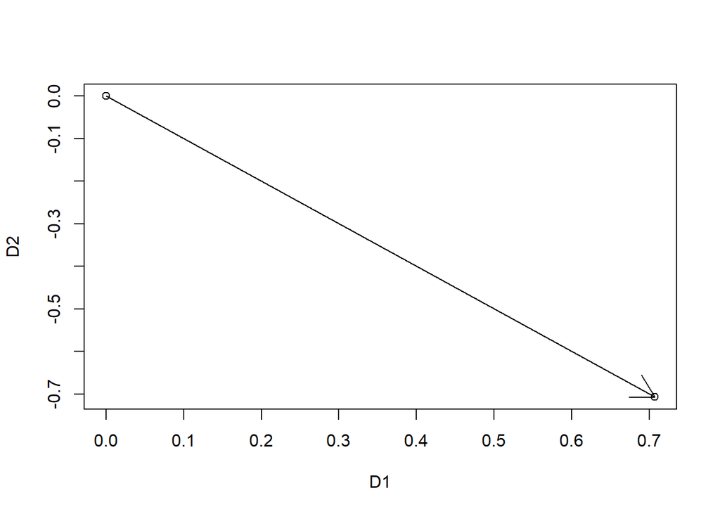

```r
#intento 1) con vector de dos dimensions, el problema es que es el mismo d1 y d2
D1 <- c(0,d1[1])
D2 <- c(0,d1[2])
plot(D1,D2)
arrows(D1[1],D2[1],D1[2],D2[2])
```

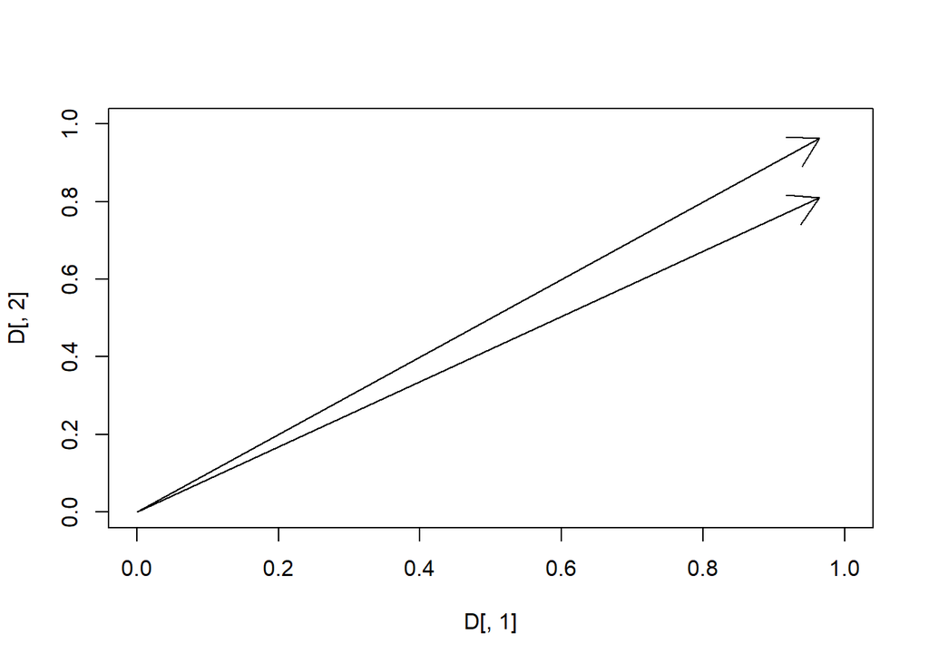

```r
#intento 2) con solo las primeras dos entradas
D1.3 <- d1.3[c(1,2)]
D2.3 <- d2.3[c(1,2)]
D1.3 <- D1.3/ norm_vec(D1.3)
D2.3 <- D2.3/ norm_vec(D2.3)
D<- rbind(D1.3,D2.3)
plot(D[,1],D[,2],type="n", xlim=c(0, 1), ylim=c(0,1))
arrows(0,0,x1 = D[c(1,1)],y1 = D[c(1,2)])
```

Para calcular el angulo entre los dos vectores utilizaremos los vectores en seis dimensiones originales y la siguiente formula.
$$d_i'd_k = L_{d_i}L_{d_k}cos(\theta_{ik})$$
por lo tanto
$$cos(\theta_{ik}) = \frac{d_i'd_k }{L_{d_i}L_{d_k}}$$
de donde
$$\theta_{ik} = cos^{-1}(\frac{d_i'd_k }{L_{d_i}L_{d_k}})$$

```r
v <- ((t(d1.3)%*%d2.3)[1]/((norm_vec(d1.3))*(norm_vec(d2.3))))
(theta <- acos(v))
```

```
## [1] 0.4687649
```

ahora para el inciso f) calcularemos la viaranza muestral generalizada. Dado que se cumple que $d_i'dj = nS_{ij}$ hacemos lo siguiente. Para primero calcular $S_n$

```r
#Duda si dividir entre 6 o 6-1
s1.3 <- (t(d1.3)%*%d1.3)[1]/(6-1)
s2.3 <- (t(d2.3)%*%d2.3)[1]/(6-1)
sc.3 <- (t(d1.3)%*%d2.3)[1]/(6-1)

Sn.3 <- matrix(c(s1.3,sc.3,sc.3,s2.3),2,2,byrow = TRUE)
det(Sn.3)
```

```
## [1] 844182191
```

```r
# comparando con la obtenida por R
X3 <- cbind(data3$x1,data3$x2)
S3 <- cov(X3)

(det(S3))
```

```
## [1] 844182191
```

para el inciso g) calculamos la $tr(S)$

```r
sum(diag(Sn.3))
```

```
## [1] 589443426354
```

##Ejercicio 4 4 Dibuja las elipsoides sólidas $\{{x|(x − \bar{x})'S^{-1}(x − \bar{x}) ≤ 1\}}$ para las tres matrices siguientes y determina los valores de los ejes mayores y menores. a)
$$S = \left(\begin{array}{cc}
5 & 4\\
4 & 5
\end{array}\right)$$
Asumimos que la media es cero, es decir $\bar{x} = 0$. Esto hara que nuestras elipses esten centradas en el origen. Los ejesY procedemos de la siguiente forma.

```r
S1 <- matrix(c(5,4,4,5),nrow = 2, byrow = T)
lambdas1 <- eigen(S1)$values
(eje.mayor <- sqrt(max(lambdas1)))
```

```
## [1] 3
```

```r
(eje.menor <- sqrt(min(lambdas1)))
```

```
## [1] 1
```

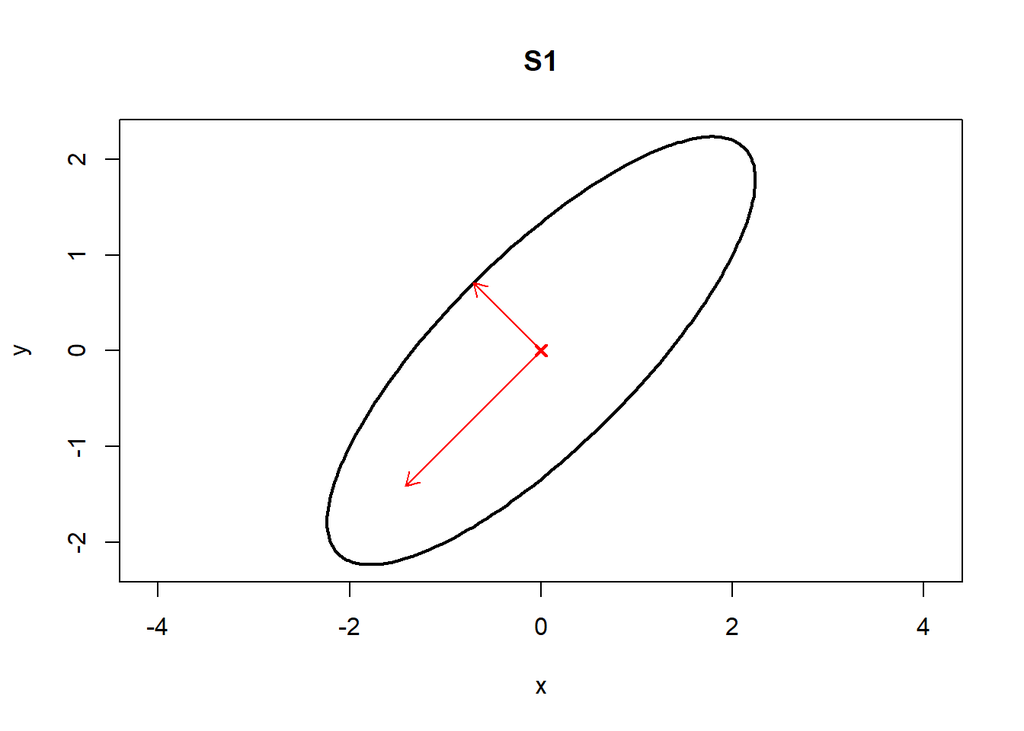

```r
mu <- c(0, 0)  #vector medias
DC <- chol(S1) # descomposición de Cholesky
angl <- seq(0, 2*pi, length.out=200)
elipse.esc <- 1 * cbind(cos(angl), sin(angl)) %*% DC # elipse escalada
elipseCentro <- sweep(elipse.esc, 2, mu, "+") # centramos en la media
plot(elipseCentro, type="l", lwd=2, asp=1, xlab="x",ylab="y", main="S1")
points(mu[1], mu[2], pch=4, lwd=2, col="red")
#Ejes en la dirección de las componentes principales:
Sinv <- solve(S1) #inversa de la matriz de covarianzas
DE <- eigen(Sinv) #descomposición espectral de Sinv
s1 <- 2 #factor de escala
s2 <- 1
arrows(x0 = mu[1], y0 = mu[2],
x1 = mu[1] + s2*DE$vectors[1,1], y1 = mu[2] + s2*DE$vectors[2,1], length = 0.1, col = "red")
arrows(x0 = mu[1], y0 = mu[2],
x1 = mu[1] + s1*DE$vectors[1,2], y1 = mu[2] + s1*DE$vectors[2,2], length = 0.1, col = "red")
```

De donde el eje mayor es 3 y el menor es 1.

b)
$$S = \left(\begin{array}{cc}
5 & -4\\
-4 & 5
\end{array}\right)$$

```r
S2 <- matrix(c(5,-4,-4,5),nrow = 2, byrow = T)
lambdas2 <- eigen(S2)$values
(eje.mayor <- sqrt(max(lambdas2)))
```

```
## [1] 3
```

```r
(eje.menor <- sqrt(min(lambdas2)))
```

```
## [1] 1
```

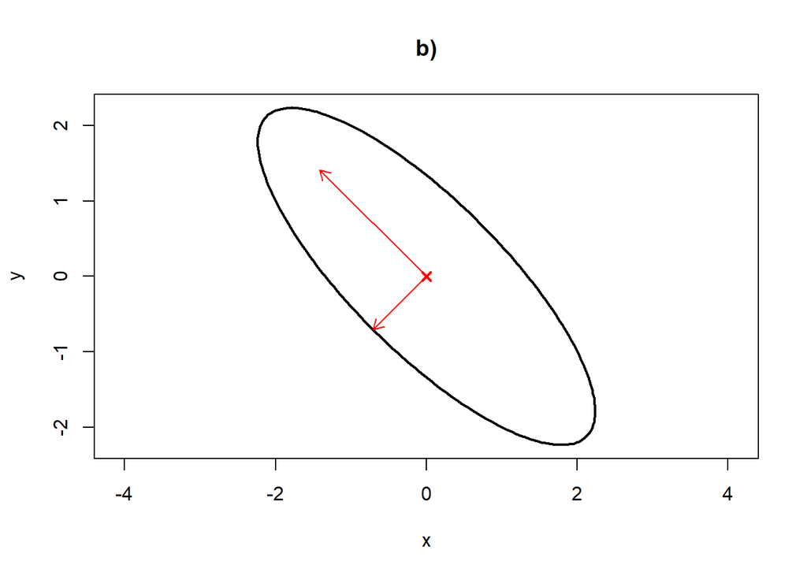

```r
mu <- c(0, 0)  #vector medias
DC <- chol(S2) # descomposición de Cholesky
angl <- seq(0, 2*pi, length.out=200)
elipse.esc <- 1 * cbind(cos(angl), sin(angl)) %*% DC # elipse escalada
elipseCentro <- sweep(elipse.esc, 2, mu, "+") # centramos en la media
plot(elipseCentro, type="l", lwd=2, asp=1, xlab="x",ylab="y", main="b)")
points(mu[1], mu[2], pch=4, lwd=2, col="red")
#Ejes en la dirección de las componentes principales:
Sinv <- solve(S1) #inversa de la matriz de covarianzas
DE <- eigen(Sinv) #descomposición espectral de Sinv
s1 <- 2 #factor de escala
s2 <- 1
arrows(x0 = mu[1], y0 = mu[2],
x1 = mu[1] + s1*DE$vectors[1,1], y1 = mu[2] + s1*DE$vectors[2,1], length = 0.1, col = "red")
arrows(x0 = mu[1], y0 = mu[2],
x1 = mu[1] + s2*DE$vectors[1,2], y1 = mu[2] + s2*DE$vectors[2,2], length = 0.1, col = "red")
```

Al igual que en el inciso anterior el eje mayor es 3 y el menor es 1.

```r
S3 <- matrix(c(3,0,0,3),nrow = 2, byrow = T)
lambdas3 <- eigen(S3)$values
(eje.mayor <- sqrt(max(lambdas3)))
```

```
## [1] 1.732051
```

```r
(eje.menor <- sqrt(min(lambdas3)))
```

```
## [1] 1.732051
```

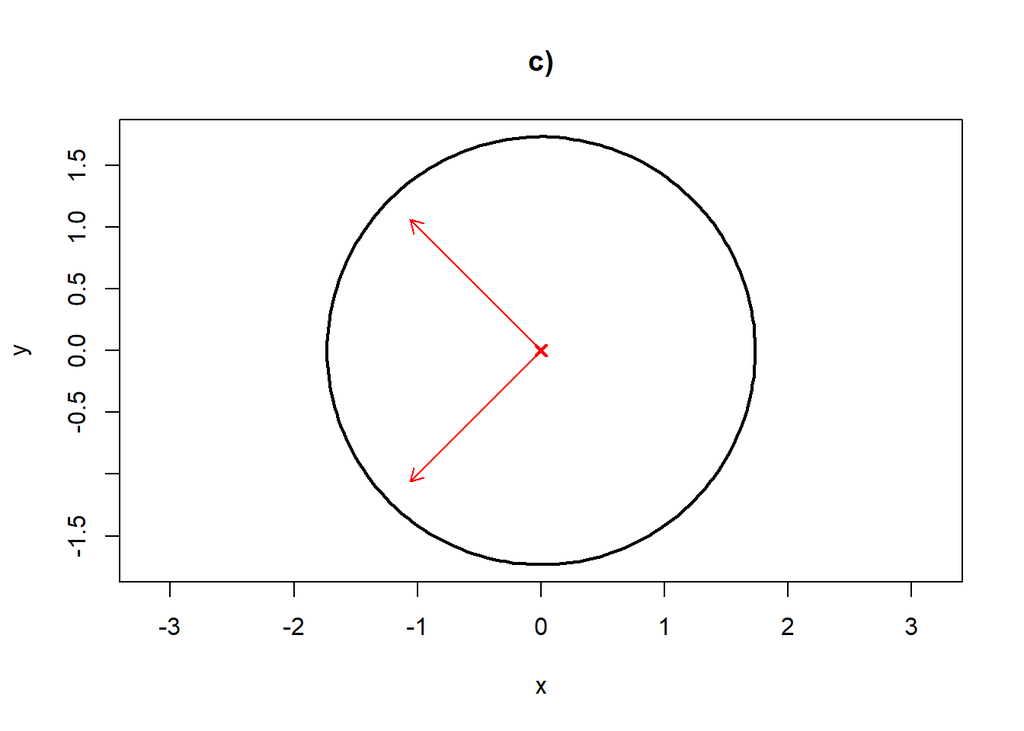

```r
mu <- c(0, 0)  #vector medias
DC <- chol(S3) # descomposición de Cholesky
angl <- seq(0, 2*pi, length.out=200)
elipse.esc <- 1 * cbind(cos(angl), sin(angl)) %*% DC # elipse escalada
elipseCentro <- sweep(elipse.esc, 2, mu, "+") # centramos en la media
plot(elipseCentro, type="l", lwd=2, asp=1, xlab="x",ylab="y", main="c)")
points(mu[1], mu[2], pch=4, lwd=2, col="red")
#Ejes en la dirección de las componentes principales:
Sinv <- solve(S1) #inversa de la matriz de covarianzas
DE <- eigen(Sinv) #descomposición espectral de Sinv
s <- 1.5 #factor de escala
arrows(x0 = mu[1], y0 = mu[2],
x1 = mu[1] + s*DE$vectors[1,1], y1 = mu[2] + s*DE$vectors[2,1], length = 0.1, col = "red")
arrows(x0 = mu[1], y0 = mu[2],
x1 = mu[1] + s*DE$vectors[1,2], y1 = mu[2] + s*DE$vectors[2,2], length = 0.1, col = "red")
```

En este caso tanto el eje menor como el mayor son 1.7 ##Ejercicio 5

Leyendo la base de datos.

```r
#read databse
file <- 'INEGIConstruccion2017.csv'
df_inegi <- read.csv(file = paste(file,sep = ""),header = T,skip = 0) #skip lines
```

Observamos que las variables están colocadas de manera continua sobre todas las columnas, son 215 variables. Queremos hacer una matriz $X$ donde sus variables sean las mencionadas anteriormente y sus oobservaciones sean los estados para enero del 2017.

Además, notamos lo siguiente: - Hay columnas faltantes. - Entre cada variable, hay un *total nacional*. (Se optará por eliminarlo, ya que produce colinealidad). - De la variable **Valor de producción generado …**, sólo hay *16* observaciones. Por lo que quitar los renglones *NO* es opción. Se hará un remuestreo con reemplazo para asignar el valor de las variables.

### 5a. $X$ configurada para operar.

Se limpiará a continuación la base de datos de forma manual, debido a que no hay un patrón definido.

```r
set.seed(42)
#copy raw data
file2 <- 'inegiClean.csv'

#clean
df_raw <- read.csv(file2,header = FALSE)
df_raw <- as.matrix(df_raw)

#data is transposed
df_raw <- t(df_raw)
df_raw[17:32,2] <- sample(df_raw[1:16,2], size = 16, replace = T)
X <- df_raw

#look
tail(X)
```

```
##         [,1]      [,2]     [,3]     [,4]     [,5]   [,6]    [,7]
## V27 2261.705 3144478.7 1716.063 1169.822  501.094 45.147 545.642
## V28 6176.806 1404806.6 5224.554 4208.895  950.857 64.802 952.252
## V29  268.718  717169.8  268.210  200.665   57.040 10.505   0.508
## V30 6582.393  533582.3 6226.744 5041.573 1113.837 71.334 355.649
## V31 3423.691 2232549.7 3310.421 2572.381  708.740 29.300 113.270
## V32 1510.317 1059265.3 1495.929 1273.993  208.743 13.193  14.388
```

###5.b Calculate the mean vector and the variance and covariance matrix

```r
mean_vec <- colMeans(X)
Sprime <- cov(X)

cat("\n Vector de medias\n")
```

```
##
##  Vector de medias
```

```r
kable(mean_vec,caption = "Vector de medias", digits = 3)
```

Vector de medias

| x |
| --- |
| 4045.648 |
| 1125180.444 |
| 3366.957 |
| 2642.589 |
| 673.024 |
| 51.344 |
| 678.692 |

```r
cat("\n Matriz de var y cov\n")
```

```
##
##  Matriz de var y cov
```

```r
kable(Sprime, col.names = c("X1","X2","X3","X4","X5","X6","X7"), digits = 3)
```

| X1 | X2 | X3 | X4 | X5 | X6 | X7 |
| --- | --- | --- | --- | --- | --- | --- |
| 12302808.82 | 791597446 | 8156502.07 | 6418338.7 | 1659753.37 | 78409.975 | 4146306.75 |
| 791597446.02 | 665503788827 | 599330930.44 | 380592172.0 | 203160295.91 | 15578462.578 | 192266515.57 |
| 8156502.07 | 599330930 | 5877226.85 | 4685110.3 | 1138165.49 | 53951.050 | 2279275.21 |
| 6418338.72 | 380592172 | 4685110.32 | 3795459.8 | 850416.39 | 39234.095 | 1733228.40 |
| 1659753.37 | 203160296 | 1138165.49 | 850416.4 | 274187.77 | 13561.327 | 521587.89 |
| 78409.98 | 15578463 | 53951.05 | 39234.1 | 13561.33 | 1155.627 | 24458.92 |
| 4146306.75 | 192266516 | 2279275.21 | 1733228.4 | 521587.89 | 24458.925 | 1867031.54 |

```r
detS <- det(Sprime)

#prove det
prodaux <- 1

#measure vars
Rprime <- cor(X) #corr matrix
n <- ncol(X) #number of vars
D <- diag(x = eigen(Sprime)$values,)

for(i in 1:n)
  prodaux <- prodaux * D[i,i] * det(Rprime)
```

##Ejercicio 6

Sea $\underline{X} \sim \mathcal{N}_{3}(\underline{\mu},\Sigma)$ con $\underline{\mu}$ y $\Sigma$ definidas como en la tarea. Determinar cuales de las sig vars son independientes y porqué:

- $X_{1} \ \text{y} \ X_{2}$: **Dependientes**, debido a que la covarianza entre ellas es distinta de cero.
- $X{2} \ \text{y} \ X_{3}$: **Independientes**, ya que la covarianza entre ellas es cero.
- $(X_{1},X_{2}) \ \text{y} \ X_{3}$: **Independientes** ya que el bloque de la matriz $\Sigma$ para $X_{1,2} \ \text{y} \ X_{3}$ tiene ceros en los traingulos superiores e inferiores.
- $\frac{(X_{1} +X_{2})}{2} \ \text{y} \ X_{3}$: **Independientes**, por el inciso anterior.
- $X_{2} \ \text{y} \ X_{2} - \frac{5}{2}X_{1} - X_{3}$: **Dependientes**. Pues ambas variables *dependen* del valor que tome $X_{2}$.

##Ejercicio 7 7. Sea $X \sim N(\mu,\Sigma)$ con
$$\mu' = (2,-3,1)$$
y
$$\Sigma = \left(\begin{array}{cc}
1 & 1 & 1\\
1 & 3 & 2 \\
1 & 2 & 2
\end{array}\right)$$

1. Encuentra la distribucion de $3X_1 - 2X_2 + X_3$

Dado que $X \sim N$, sabemos que sus marginales tambien lo seran. Tambien podemos afirmar que cualquier combinacion lineal sigue tambien una distribucion normal. Para resolver este inciso utilizamos la siguiente fomula.
$$a'X \sim N(a'\mu, a'\Sigma a)$$
Por lo cual obtenemos la media y varianza de la siguiente manera.

```r
v = c(3,-2,1)
mu.7 <- c(2,-3,1)
s.7 <- matrix(c(1,1,1,1,3,2,1,2,2), nrow = 3, ncol = 3, byrow = TRUE)
(MU.7 <- as.numeric(t(v)%*%mu.7))
```

```
## [1] 13
```

```r
(S.7 <- as.numeric(t(v)%*%s.7%*%v))
```

```
## [1] 9
```

Por lo tanto $3X_1 - 2X_2 + X_3 \sim N(13,9)$

2. Encontrar un vector $a$ tal que $X_2$ y $X_2 - a'(X_1,X_2)'$ sean independientes.

Para resolver esto, basta con encontrar $a\epsilon \Re^2$ tal que la covarianza de $X_2$ y $X_2 - a'(X_1,X2)'$ sea cero.
$$\begin{array}{l}
cov(X_2,X_2 - a'(X_1,X_2)') = cov(X_2, X_2 - a_1X_1 + a_2X_2)\\
= cov(X_2,X_2) - a_1cov(X_1,X_2) - a_2cov(X_1,X_2)\\
= S_{22} -a_1S_{12} - a_2S_{22}
= 3 -a_1 - 3a_2
\end{array}$$

Por lo tanto
$$cov(X_2,X_2 - a'(X_1,X_2)') = 0$$
$$\Leftrightarrow 3 -a_1 - 3a_2 = 0$$
$$\Leftrightarrow a_1+3a_2 = 3$$
Para lo cual existe toda una recta de combinaciones que cumple estas condiciones. Basta con tomar
$$\begin{array}{l}
a_1 = 0 \\
a_2 = 1
\end{array}$$
##Ejercicio 8

Sea $y_{i} = Ax_{i} + b, \quad i = 1,\dots,n$, mostrar que

### 8.i) $\bar{y} = A\bar{x} + b$

Sea $\bar{y} = A\bar{x} + b$, vemos que:
$$\begin{equation*}
\bar{y} = \frac{1}{n}\sum_{i=1}^{m}y_{i} =\frac{1}{n}\sum_{i=1}^{m}{(Ax_{i} + b)} = \frac{1}{n}\sum_{i=1}^{m}(Ax_{i}) + b
= A \frac{1}{n}\sum_{i=1}^{m}(x_{i}) + b = A\bar{x} + b.
\end{equation*}$$

### 8.ii) $S_{y} = A S_{y} A^{T}$

Usando el teorema de proba2 que dice que
$$\text{var}(A\underline{X}) = A \text{var}(\underline{X}) A^{T},$$
entonces tendremos que
$$S_{y} = \text{var}{\underline{Y}} = \text{var}(A\underline{X} + b) = \text{var}(A\underline{X}) = A\text{var}(\underline{X})A^{T} = AS_{x}A^{T}.$$
##Ejercicio 9 a) Para el vector de medias sabemos que el vector de medias de una matriz $X$ está dado por $\bar{x}$= $\begin{bmatrix} \bar{x_1}\\ \bar{x_2}\end{bmatrix}$ con $\bar{x_i}$=$\frac{1}{n}\sum_{i=1}^{n}x_{1i}$

Por otro lado, $X_1^T1$= $\begin{bmatrix} x_{11}\ x_{12}\ \cdots \ x_{147}\\ \ x_{21}\ x_{22}\ \cdots\ x_{247}\end{bmatrix} \begin{bmatrix} 1 \\ \vdots \\ 1\end{bmatrix}$=$\begin{bmatrix} \sum_{i=1}^{n}x_{1i}\\ \sum_{i=1}^{n}x_{2i}\end{bmatrix}$=$\begin{bmatrix} 110-9\\ 432.5\end{bmatrix}$. Por lo tanto, el vector de medias es: $\bar{x_1}=$X_1^T1$= $\begin{bmatrix} 2.36\\ 9.2\end{bmatrix}$

```r
a<-c(110.9, 432.5) #x^t1
(vec_med<-a/47)
```

```
## [1] 2.359574 9.202128
```

Sabemos que S (matriz de varianzas y covarianzas) se escribe como $S= \frac{1}{n} \Sigma$ con $\Sigma=A^TA$ y $A=X-11^TX$ donde $X$ es una mátriz de tamaño nxp que contiene las observaciones y $1$ es un vector de unos de tamaño nxp. En este caso tenemos $n=47$. Si desarrolamos, $\Sigma=X^TX-\frac{2}{n}(X^T1)(X^T1)^T+\frac{1}{n^2}(X^T1)1^T1(X^T1)^T$. Ya tenemos los resultados de $X^TX$ y de $X^T1$. Calculamos entonces la S:

```r
xtx<-matrix(c(265.12, 1029.62, 1029.62,4069.71),nrow=2,byrow=T)
uno<-c(rep(1, 47))
a<-c(110.9, 432.5) #x^t1
```

```r
sigma<-xtx-(2/47)*a %*% t(a)+(1/47)**2*a%*%t(uno)%*%uno%*%t(a)
```

```r
(s=(1/47)*sigma)
```

```
##            [,1]     [,2]
## [1,] 0.07325939 0.193703
## [2,] 0.19370303 1.910421
```